# Confusion Matrix Calculations

```r
library(colorspace)
```

This notebook is an exploratory look at confusion matrices and Cohen’s Kappa coefficient with my simulated data scenarios in mind. Analysis of the data happens in “Simulated Data Analysis.Rmd”

# Confusion Matrixes

To do this, I employ a confusion matrix/kappa coefficient method. A confusion matrix is just a contingency table with the intended categories of variables on one side, and the actual classification of the variables by some model on the other side.

E.g.:

```
                actual
detected.as      discriminating uncorrelated Sum
  discriminating             15            2  17
  uncorrelated                3           10  13
  Sum                        18           12  30
```

We have 15 true positives in the upper left, 10 true negatives in the lower right, and then 2 false positives in the upper right, and 3 false negatives in the lower left.

## Kappa coefficient

Using the confusion matrix, we can calculate Cohen’s kappa which summarizes the ability of a model to classify things correctly.

Cohen’s kappa is defined as:

$$\kappa = \frac{ p_o - p_e}{1-p_e}$$

where $p_o$ is observed proportionate agreement:

$$p_o = \frac{\text{true positives} + \text{true negatives}}{\text{total}}$$
In my above example, $p_o = (15+10)/30$ or 0.8333

and $p_e$ is probability of random agreement:

$$p_e = (p_{(\text{detected discr})}\times p_{(\text{actual discr})}) + (p_{(\text{detected uncorr})} \times p_{(\text{actual uncorr})})$$
That is, it uses the row and column summs from the contingency table to calculate probabilities. For example, 17/30 variables were detected as discriminating, so $p_{\text{(detected discr)}} = 0.5666$

```r
pe = (17/30 * 18/30) + (12/30 * 13/30)
pe
```

```
[1] 0.5133333
```

So K =

```r
K = (0.8333333 - pe)/(1-pe)
K
```

```
[1] 0.6575342
```

# Applying to PLS-DA and PCA

In order to apply this to PLS-DA, I’ll use the common cuttoff of VIP > 1 to indicate whether a variable is discriminating or not. The name of the variable contains information on whether it was meant to be discriminating or not, so I can then create a confusion matrix and calculate K

It’s more difficult to decide how to do this for PCA since there are several ways to go about it. Often correlation plots are used which plot loadings of the first two PCs with a circle representing a correlation coefficient cutoff, usually of 0.5. Variables with correlations greater than 0.5 are considered significantly correlated with either PC1, PC2 or both, depending on the location of the variable in loading space.

Rather than using a cutoff of r = 0.5, I’ll use a cutoff of r = 0.38 which is what would be significant with n = 20 observations

# Load data

```r
needle.pls <- read_rds(here('data', 'models', 'needle-pls.rds'))
```

[output not shown]

# Functions

`conf_pca()` creates a confusion matrix for PCA models produced by `opls()` by calculating correlation of variables to scores for the first two principal components. Then, it creates a cutoff correlation which is equivalent to the $r$ you would get if $p = 0.05$ in a correlation test. It then categorizes variables as discriminating or not based on this cutoff.

`conf_pls()` creates a confusion matrix for PLS models produced by `opls()` by extracting VIP scores and assigning variables with VIP > 1 as discrminating.

`calc_kappa()` takes the results of `conf_pca()` or `conf_pls()` and calculates Cohen’s Kappa based on a confusion matrix.

```r
conf_pca <- function(pca.model){
  scores <- get_scores(pca.model)
  data <- pca.model@suppLs$xModelMN

  #figure out appropriate cutoff by solving for the r that gives p < 0.05 given n

  n = pca.model@descriptionMC[1,1] %>% as.numeric()
  t = qt(0.05, n)
  r = sqrt(-(t^2)/(-t^2 - n + 2)) #solved t stat calculation for r

  cor(scores[2:3], data) %>%
    t() %>%
    as_tibble(rownames = "Variable") %>%
    rowwise(.) %>%
    mutate(distance = sqrt(sum((c(p1, p2) - c(0, 0))^2))) %>%
    # if corr distance > 0.38, then its "important" variable
    mutate(detect_discr = ifelse(distance > r, TRUE, FALSE),
           is_discr = ifelse(str_detect(Variable, "D"), TRUE, FALSE))
}


conf_pls <- function(pls.model){
  get_VIP(pls.model) %>%
    mutate(detect_discr = ifelse(VIP > 1, TRUE, FALSE),
           is_discr = ifelse(str_detect(Variable, "D"), TRUE, FALSE))
}

calc_kappa <- function(confusion_df) {
  confusion_df %>%
    select(detect_discr, is_discr) %>%
    as.matrix() %>%
    cohen.kappa() %>%
    .$kappa %>%
    data_frame(kappa = .)
}
```

## Control

### Calculate Cohen’s Kappa

**PLS-DA kappas**

```r
# Get VIP scores
control.pls.k <-
  control.pls %>%
  map(conf_pls) %>%
  map_df(calc_kappa, .id = "dataset") %>%
  rename(pls.k = "kappa")
```

**Join all kappas**

| pca.k_mean | pca.k_sd | pls.k_mean | pls.k_sd |
| --- | --- | --- | --- |
| 0.3023451 | 0.1066498 | 0.9449567 | 0.0699285 |

### Build Plot

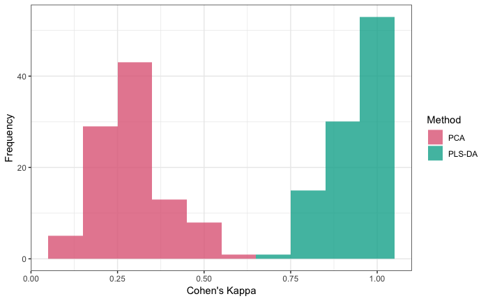

```r
control.k.plotdata <-
  control.k %>%
  gather(-dataset, key = "Method", value = "Cohen's Kappa") %>%
  mutate(Method = as.factor(Method) %>% fct_recode(PCA = "pca.k", `PLS-DA` = "pls.k"))

control.p <-
  ggplot(control.k.plotdata) +
  geom_histogram(aes(x = `Cohen's Kappa`, fill = Method),
                 position = "identity", alpha = 0.8,
                 binwidth = 0.1) +
  # geom_density(aes(x = `Cohen's Kappa`, fill = Method), alpha = 0.7, trim = TRUE) +
  scale_fill_discrete_qualitative(palette = "Dark 3") +
  theme_bw() +
  labs(x = "Cohen's Kappa", y = "Frequency")
control.p
```

# Needle-in-a-haystack

## Calculate Cohen’s Kappa

**PCA kappas**

```r
needle.pca.k <-
  needle.pcas %>%
  map(conf_pca) %>%
  map_df(calc_kappa, .id = "dataset") %>%
  rename(pca.k = "kappa")
```

**PLS-DA kappas**

```r
needle.pls.k <-
  needle.pls %>%
  map(conf_pls) %>%
  map_df(calc_kappa, .id = "dataset") %>%
  rename(pls.k = "kappa")
```

**Join all kappas**

```r
needle.k <- full_join(needle.pca.k, needle.pls.k)
needle.k %>%
  summarize(pca.k_mean = mean(pca.k),
            pca.k_sd = sd(pca.k),
            pls.k_mean = mean(pls.k),
            pls.k_sd = sd(pls.k))
```

| pca.k_mean | pca.k_sd | pls.k_mean | pls.k_sd |
| --- | --- | --- | --- |
| -0.1025275 | 0.1346032 | 0.8028457 | 0.1376157 |

### Build plot

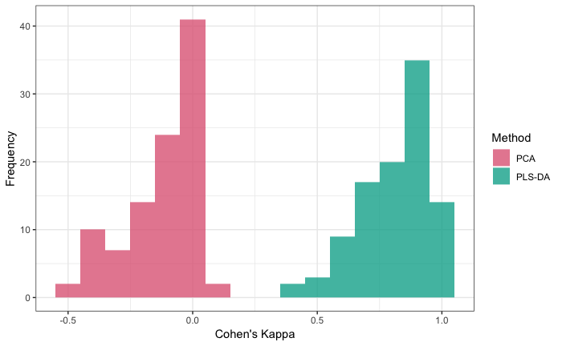

```r
needle.k.plotdata <-
  needle.k %>%
  gather(-dataset, key = "Method", value = "Cohen's Kappa") %>%
  mutate(Method = as.factor(Method) %>% fct_recode(PCA = "pca.k", `PLS-DA` = "pls.k"))

needle.p <-
  ggplot(needle.k.plotdata) +
  geom_histogram(aes(x = `Cohen's Kappa`, fill = Method),
                 position = "identity", alpha = 0.8,
                 binwidth = 0.1) +
  # geom_density(aes(x = `Cohen's Kappa`, fill = Method), alpha = 0.7, trim = TRUE) +
  scale_fill_discrete_qualitative(palette = "Dark 3") +
  theme_bw() +
  labs(x = "Cohen's Kappa", y = "Frequency")
needle.p
```

# Plot

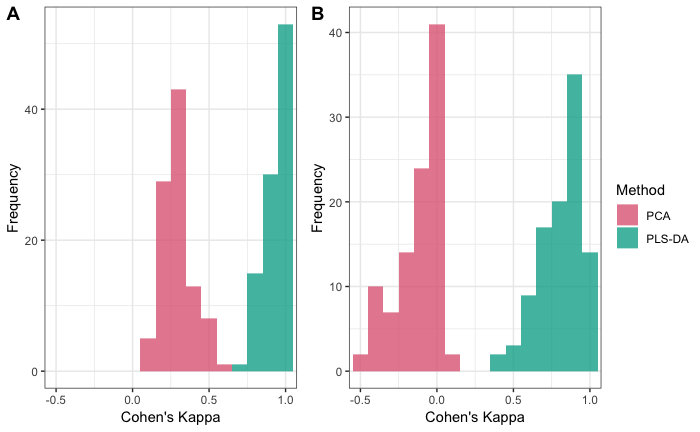

```r
panels <-
  plot_grid(control.p + theme(legend.position = "none")+ coord_cartesian(xlim = c(-0.5, 1)),
            needle.p + theme(legend.position = "none")+ coord_cartesian(xlim = c(-0.5, 1)),
            nrow = 1,
            ncol = 2,
            labels = "AUTO")
fig2 <-
  plot_grid(panels, get_legend(control.p),
            rel_widths = c(1, 0.15))
fig2
save_plot(here("figs", "fig2.png"), fig2, ncol = 2)
```

Cohen’s Kappa for PCA and PLS-DA important variables under control (a) and needle-in-a-haystack (b) scenarios.